# MDA-U12-Losungen

```python
import numpy as np
import matplotlib.pyplot as plt
import matplotlib.cm as cm

import warnings
warnings.filterwarnings(action='ignore')
```

### Kurvenintegrale

1. Berechnen Sie das Linienintegral

$$ \int_C \left[y \mathrm{d}x + (x^2 +xy)\mathrm{d}y\right] $$

von A = (0,0) nach B = (2,4) entlang

- einer geradlinigen Verbindung und
- entlang der Parabel $y = x^2$.
2. Welche Arbeit verrichtet das Kraftfeld

$$\vec{\mathbf{F}}(x,y,z) = \left( \begin{array}{c} xy \\ 1 \\ yz \end{array} \right )$$

an einer Masse, wenn diese längs der Schraubenlinie $$ \vec{\mathbf{r}}(t) = \left( \begin{array}{c} \cos(t) \\ \sin(t) \\ t \end{array} \right )$$

von $P_1(t = 0)$ nach $P_2(t = 2\pi)$ bewegt wird.

3. Überprüfen Sie ob folgende Vektorfelder konservativ sind und berechnen Sie falls möglich die entsprechende Potentialfunktion und den Wert des Kurvenintegrals von (0,0) nach (1,1) entlang eines beliebigen Weges.
- $\vec{\mathbf{F}} = \left(\begin{array}{c} 2x + y \\ xy +y^2\end{array}\right)$
- $\vec{\mathbf{F}} = \left(\begin{array}{c} y^2\sin(x) -2x \\ -2y\cos(x) + 4y\end{array}\right)$

#### Lösungen

*1)*

- Parametrisierung der geradlinigen Verbindung $x(t) = t, y(t) = 2t$
- Umschreibung des Integrals als bestimmtes Integral über t: $$\int_0^2 \left[2t \mathrm{d}t + (t^2 +2t^2) \cdot 2 \cdot \mathrm{d}t\right] = \int_0^2 \left[2t + 6t^2\right]\mathrm{d}t = \left[t^2 + 2t^3\right]_0^2 = 20$$
- Parametrisierung der Parabel: $x(t) = t, y(t) = t^2$
- Umschreibung des Integrals als bestimmtes Integral über t: $$\int_0^2 \left[t^2 \mathrm{d}t + (t^2 + t^3) \cdot 2t \cdot \mathrm{d}t\right] = \int_0^2 \left[t^2 + 2t^3 + 2t^4\right]\mathrm{d}t = \left[\dfrac{t^3}{3} + \dfrac{t^4}{2} + \dfrac{2t^5}{5}\right]_0^2 = \dfrac{8}{3} + \dfrac{16}{2} + \dfrac{64}{5} = \dfrac{40 + 120 + 192}{15} = \dfrac{352}{15} \approx 23.47$$

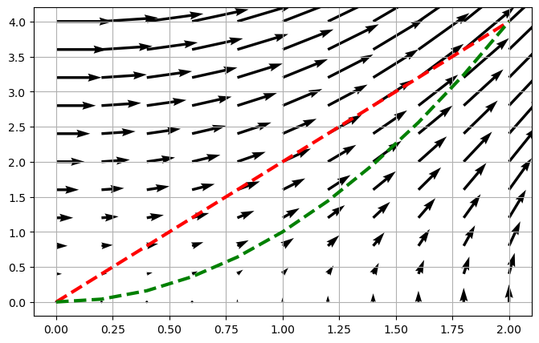

```python
fig = plt.figure(figsize=(8,5))

x = np.linspace(0, 2, 11)
y = np.linspace(0 ,4, 11)
X,Y= np.meshgrid(x,y)
ax1 = fig.add_subplot(111)
ax1.quiver(X, Y, Y, X**2+X*Y, scale_units='xy', angles='xy', scale=16)
ax1.plot(x,2*x, color='red', linestyle='--', linewidth=3)
ax1.plot(x,x**2, color='green', linestyle='--', linewidth=3)
ax1.grid()
plt.show()
```

*2)*

allgemeine Form des Kurvenintegrals: $\int \vec{\mathbf{F}}^{\scriptscriptstyle \mathrm{T}} \mathrm{d}\vec{\mathbf{r}} = \int \vec{\mathbf{F}}^{\scriptscriptstyle \mathrm{T}} \dot{\vec{\mathbf{r}}} \, \mathrm{d}t$

- ersetzen von $x$ und $y$ im Vektorfeld durch die Komponenten im Ortsvektor

$$\vec{\mathbf{F}}(t) = \left[ \begin{array}{c} \cos(t) \sin(t) \\ 1 \\ t \sin(t) \end{array} \right]$$

- Bestimmung des Skalarproduktes

$$ \vec{\mathbf{F}}^{\scriptscriptstyle \mathrm{T}} \dot{\vec{\mathbf{r}}} = \left[ \begin{array}{c} \cos(t) \sin(t) \\ 1 \\ t \sin(t) \end{array} \right]^{\scriptscriptstyle \mathrm{T}}\left[ \begin{array}{c} -\sin(t) \\ \cos(t) \\ 1 \end{array} \right] = - \cos(t) \sin^2(t) + \cos(t) + t \sin(t)$$

- Bestimmung des Integrals

$$\int_0^{2\pi} \left[- \cos(t) \sin^2(t) + \cos(t) + t \sin(t)\right] \mathrm{d}t = \left[-\dfrac{\sin^3(t)}{3} + \sin(t) + \sin(t) - t \cos(t)\right]_0^{2\pi} = -2\pi$$

*3)*

#### 1. Vektorfeld

z-Komponente der Rotation im kartesischen Koordinatensystem: $\dfrac{\partial F_y}{\partial x} - \dfrac{\partial F_x}{\partial y} = y - 1 \ne 0$

#### 2. Vektorfeld

z-Komponente der Rotation im kartesischen Koordinatensystem: $\dfrac{\partial F_y}{\partial x} - \dfrac{\partial F_x}{\partial y} = 2y\sin(x) - 2y\sin(x) = 0$

Bestimmungsgleichungen für die Potentialfunktion: $\dfrac{\partial \phi}{\partial x} = y^2\sin(x) - 2x, \; \dfrac{\partial \phi}{\partial y} = -2y\cos(x) + 4y$

unbestimmte Integration $$ \phi(x,y) = \int\left[ y^2\sin(x) - 2x\right] \mathrm{d}x = -y^2\cos(x) - x^2 + K(y)$$

Ableitung und Vergleich $$ \dfrac{\partial \phi}{\partial y} = -2y\cos(x) + \dfrac{\mathrm{d} K(y)}{\mathrm{d}y} \equiv -2y\cos(x) + 4y \;\; \hookrightarrow K(y) = \int 4y \mathrm{d}y = 2y^2 + C$$

Potentialfunktion: $$ \phi(x,y) = -y^2\cos(x) - x^2 + 2y^2 + C$$

Kurvenintegral: $$ \int \vec{\mathbf{F}}^{\scriptscriptstyle \mathrm{T}} \mathrm{d}\vec{\mathbf{r}} =\phi(1,1) - \phi(0,0) = -\cos(1) + 1$$

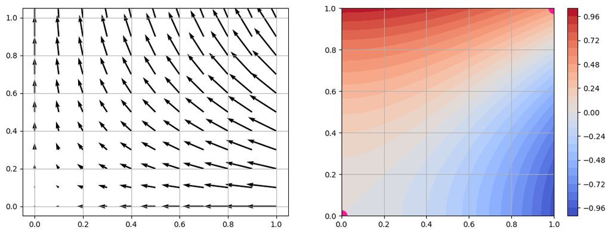

```python
fig = plt.figure(figsize=(14,5))

x = np.linspace(0, 1, 11)
y = np.linspace(0 ,1, 11)
X,Y= np.meshgrid(x,y)
ax1 = fig.add_subplot(121)
ax1.quiver(X, Y, Y**2*np.sin(X)-2*X, -2*Y*np.cos(X) + 4*Y, scale_units='xy', angles='xy', scale=16)
ax1.grid()

x = np.linspace(0, 1, 101)
y = np.linspace(0 ,1, 101)
X,Y= np.meshgrid(x,y)
Z = -Y**2*np.cos(X) - X**2 + 2*Y**2
ax2 = fig.add_subplot(122)
clb = ax2.contourf(X, Y, Z, 25, cmap=cm.coolwarm)
ax2.scatter([0,1],[0,1],s=200,marker='o',color='deeppink')
ax2.grid()
fig.colorbar(clb, ax=ax2)

plt.show()
```